# Daniels and Hughes Bayesian Bivariate Meta Analysis

- Show All Code
- Hide All Code
- View Source

Author

Ananda Biswas

Published

November 5, 2026

## Background

Vickers et al presented OS and PFS data from a network of evidence drawn from randomized clinical trials in advanced non-small cell lung cancer (NSCLC)(Vickers et al. 2019). The data include log hazard ratios with standard errors (SEs) for OS and PFS. These data include $34$ samples ($1$ trial included $2$ subgroups, which were entered as separate trials). The maximum length of follow-up for these trials ranged from $1.0$ to $5.9$ years, with median follow-up ranging from $0.3$ to $1.4$ years.

## Required Libraries

**Show/Hide Code**

```r
library(openxlsx)

library(gt)
library(tidyverse)

library(cmdstanr)
```

## Loading Data

**Show/Hide Code**

```r
df1 <- read.xlsx(data.path, sheet = 1)
```

## Initial Sanity Checks

**Show/Hide Code**

```r
str(df1)
```

```
'data.frame':   34 obs. of  10 variables:
 $ Study    : chr  "Study 1" "Study 2" "Study 3" "Study 4" ...
 $ HR.OS    : num  0.741 0.756 1.277 1.01 0.43 ...
 $ OS.ln.HR : num  -0.3 -0.28 0.244 0.01 -0.844 ...
 $ OS.se    : num  0.18 0.25 0.165 0.141 0.189 0.198 0.269 0.126 0.184 0.068 ...
 $ HR.PFS   : num  0.72 0.92 1.12 1.31 0.54 ...
 $ PFS.ln.HR: num  -0.3285 -0.0834 0.1125 0.27 -0.6162 ...
 $ PFS.se   : num  0.177 0.255 0.168 0.134 0.17 0.186 0.264 0.126 0.137 0.06 ...
 $ n1       : num  82 34 73 136 95 75 42 125 109 622 ...
 $ n2       : num  73 42 74 138 86 69 39 125 110 618 ...
 $ non.prop : chr  "0" "0" "0" "1" ...
```

**Show/Hide Code**

```r
dim(df1)
```

```
[1] 34 10
```

Snapshot of NSCLC Data

| Study | HR.OS | OS.ln.HR | OS.se | HR.PFS | PFS.ln.HR | PFS.se | n1 | n2 | non.prop |
| --- | --- | --- | --- | --- | --- | --- | --- | --- | --- |
| Study 1 | 0.7408182 | -0.3000 | 0.180 | 0.7200029 | -0.3285 | 0.177 | 82 | 73 | 0 |
| Study 2 | 0.7557837 | -0.2800 | 0.250 | 0.9199831 | -0.0834 | 0.255 | 34 | 42 | 0 |
| Study 3 | 1.2769827 | 0.2445 | 0.165 | 1.1190723 | 0.1125 | 0.168 | 73 | 74 | 0 |
| Study 4 | 1.0100502 | 0.0100 | 0.141 | 1.3099645 | 0.2700 | 0.134 | 136 | 138 | 1 |
| Study 5 | 0.4299871 | -0.8440 | 0.189 | 0.5399925 | -0.6162 | 0.170 | 95 | 86 | 1 |
| Study 6 | 0.6999825 | -0.3567 | 0.198 | 0.7499866 | -0.2877 | 0.186 | 75 | 69 | 1 |

## Derived Quantities

**Show/Hide Code**

```r
df1$weight <- 1 / (df1$OS.se)^2
```

## Generating Treatment Effect on Surrogate Endpoint in New Trials

**Show/Hide Code**

```r
range(df1$HR.PFS)
```

```
[1] 0.2034164 2.8662369
```

**Show/Hide Code**

```r
new.data <- data.frame(PFS.ln.HR = log(seq(0.2, 3, length = 1000)))
```

## Model

Consider a meta-analysis of $N$ clinical trials each of which, for simplicity, involves the comparison of two treatments.

In the $i-$th trial,

- $\theta_i$ denotes the true treatment difference on the clinical outcome (true endpoint),
- $\gamma_i$ denotes the true treatment difference on the response variable (surrogate endpoint).

We assume that we have estimates $\widehat{\theta_i}$ and $\widehat{\gamma_i}$, respectively, available from each trial and that the size of each study is sufficiently large, that $(\widehat{\theta_i}, \widehat{\gamma_i})$ is normally distributed about $(\theta_i, \gamma_i)$.

Within the $i-$th clinical trial, Daniels and Hughes (Daniels and Hughes 1997) assume that the following model applies:

$$\begin{pmatrix}
\hat{\theta}_i\\
\hat{\gamma}_i
\end{pmatrix}
\mid
\theta_i,
\gamma_i
\sim
N\left(
\begin{pmatrix}
\theta_i\\
\gamma_i
\end{pmatrix},
\begin{pmatrix}
\sigma_i^2 & \rho_i\sigma_i\delta_i\\
\rho_i\sigma_i\delta_i & \delta_i^2
\end{pmatrix}
\right) \tag{1}$$
where

- $\sigma_i^2$ and $\delta_i^2$ are variances that reflect sampling variation
- $\rho_i$ is the correlation between the estimated treatment differences *conditional upon the true differences*.

Considering $\gamma_i$’s as **fixed effects**, we assume a simple linear model to describe the relationship between $\theta_i$ and $\gamma_i$ across the $N$ clinical trials

$$\theta_i \mid \gamma_i \sim N(\alpha + \beta\gamma_i, \tau^2). \tag{2}$$

By combining the within-trial distribution 1 with the between-trials distribution 2, we obtain a bivariate normal distribution:

$$\begin{pmatrix}
\hat{\theta}_i\\
\hat{\gamma}_i
\end{pmatrix}
\sim
N\left(
\begin{pmatrix}
\alpha + \beta\gamma_i\\
\gamma_i
\end{pmatrix},
\begin{pmatrix}
\sigma_i^2 + \tau^2 & \rho_i\sigma_i\delta_i\\
\rho_i\sigma_i\delta_i & \delta_i^2
\end{pmatrix}
\right) \tag{3}$$

Note that,

$$E(\hat{\theta}_i \mid \gamma_i)
=
E\left[
E(\hat{\theta}_i \mid \theta_i, \gamma_i)
\mid \gamma_i
\right]
=
E(\theta_i \mid \gamma_i)
=
\alpha + \beta\gamma_i$$

and

$$\begin{aligned}
\operatorname{Var}(\hat{\theta}_i \mid \gamma_i)
&=
E\left[
\operatorname{Var}(\hat{\theta}_i \mid \theta_i, \gamma_i)
\mid \gamma_i
\right]
+
\operatorname{Var}\left(
E(\hat{\theta}_i \mid \theta_i, \gamma_i)
\mid \gamma_i
\right) \\[1em]
&=
E(\sigma_i^2 \mid \gamma_i)
+
\operatorname{Var}(\theta_i \mid \gamma_i) \\[1em]
&=
\sigma_i^2 + \tau^2.
\end{aligned}$$

## Surrogacy Criteria

A strong surrogate relationship (Bujkiewicz et al. 2026) is one with

- $\alpha = 0$, to ensure that no treatment effect on the surrogate endpoint implies no treatment effect on the final clinical outcome
- $\beta \neq 0$, establishing a relationship between treatment effects on the surrogate and final clinical outcomes
- $\tau^2 = 0$, implying that we can predict $\theta_i$ perfectly given $\gamma_i$.

In practice, we consider a surrogate relationship strong if all the following is true:

- the $95\%$ interval for the intercept $\alpha$ includes zero
- the $95\%$ interval for the slope $\beta$ does not include zero
- the conditional variance $\tau^2$ along with its upper interval is small.

## Model Fitting

### Preparing data for STAN

**Show/Hide Code**

```r
N <- nrow(df1)

DH.data <- list(
  N = N,
  theta_hat = df1$OS.ln.HR,
  gamma_hat = df1$PFS.ln.HR,
  se_theta = df1$OS.se,
  se_gamma = df1$PFS.se
)
```

### STAN Model

Here is a suitable STAN model.

**Show/Hide Code**

```r
DH.model.file <- "Daniels_Hughes_Bivariate_Meta_Analysis.stan"
```

```stan
data {
  int<lower=1> N;

  vector[N] theta_hat;
  vector[N] gamma_hat;

  vector<lower=0>[N] se_theta;
  vector<lower=0>[N] se_gamma;
}

parameters {
  vector[N] gamma;

  real alpha;
  real beta;

  real<upper=log(2)> log_tau;

  real<lower=0, upper=0.999> rho_w;
}

transformed parameters {

  real<lower=0> tau = exp(log_tau);
  real<lower=0> tau_sq = square(tau);
}

model {

  // priors
  alpha ~ normal(0, sqrt(1000));
  beta  ~ normal(0, sqrt(1000));

  gamma ~ normal(0, sqrt(1000));

  rho_w ~ uniform(0, 0.999);

  target += log_tau - log(2);

  // combined model
  for (i in 1:N) {

    vector[2] y_obs = [theta_hat[i], gamma_hat[i]]';

    vector[2] mu = [alpha + beta * gamma[i], gamma[i]]';

    matrix[2,2] Sigma;

    Sigma[1,1] = square(se_theta[i]) + square(tau);
    Sigma[1,2] = rho_w * se_theta[i] * se_gamma[i];

    Sigma[2,1] = Sigma[1,2];
    Sigma[2,2] = square(se_gamma[i]);

    y_obs ~ multi_normal(mu, Sigma);
  }
}
```

As IPD are not available, assume that the $\rho_i$’s for the trials with no IPD available are equal to some common value $\rho_w$, we **assume** a positive association between `HR.OS` and `HR.PFS`, accordingly we set a priori $\rho_w \sim U(0, 0.999)$.

Taking a Bayesian approach, we place non-informative prior distributions on the fixed effects, $\gamma_i$ and the regression coefficients:

$$\alpha \sim N(0, A_{\alpha})$$

$$\beta \sim N(0, A_{\beta})$$

$$\gamma_i \sim N(0, A_{\gamma_i})$$

where $A_{\alpha}$, $A_{\beta}$, $A_{\gamma_i}$ are large numbers; here they are taken to be $1000$.

For the between-studies variance, $\tau^2$, a uniform prior is set on $\tau$ : $\tau \sim U(0, 2)$.

For smoother posterior sampling, $\tau$ has been transformed to log-scale and so has been the prior.

$$\text{Since } \tau \sim U(0, 2); \;\; \text{say } Y = \ln(\tau), \text{ consequently }
f_Y(y) =
\begin{cases}
\dfrac{e^y}{2}, & y < \ln 2,\\[6pt]
0, & \text{otherwise}.
\end{cases}$$

An uniform prior on $\tau$ was also used by Vickers (Vickers 2025).

### Model Compilation

**Show/Hide Code**

```r
DH.model <- cmdstan_model(stan_file = DH.model.file)
```

### Running HMC

**Show/Hide Code**

```r
n.chains <- 3
n.samples.per.chain <- 150000

n.posterior.samples <- n.chains * n.samples.per.chain
```

**Show/Hide Code**

```r
init <- function() {
  list(
    gamma = rep(0, N),
    z = rep(0, N),
    alpha = 0,
    beta = 0,
    log_tau = log(0.2),
    rho_w = 0.25
  )
}
```

**Show/Hide Code**

```r
fit <- DH.model$sample(
  data = DH.data,
  chains = n.chains,
  parallel_chains = n.chains,
  iter_warmup = 50000,
  iter_sampling = n.samples.per.chain,
  adapt_delta = 0.95,
  max_treedepth = 25,
  init = init,
  refresh = 0
)
```

```
Running MCMC with 3 parallel chains...

Chain 2 finished in 257.8 seconds.
Chain 3 finished in 258.0 seconds.
Chain 1 finished in 370.3 seconds.

All 3 chains finished successfully.
Mean chain execution time: 295.4 seconds.
Total execution time: 370.4 seconds.
```

### HMC Diagnostics

**Show/Hide Code**

```r
fit$cmdstan_diagnose()
```

```
Checking sampler transitions treedepth.
Treedepth satisfactory for all transitions.

Checking sampler transitions for divergences.
No divergent transitions found.

Checking E-BFMI - sampler transitions HMC potential energy.
E-BFMI satisfactory.

Rank-normalized split effective sample size satisfactory for all parameters.

Rank-normalized split R-hat values satisfactory for all parameters.

Processing complete, no problems detected.
```

## Posterior Summaries of Parameters of Interest

### Posterior Draws

**Show/Hide Code**

```r
posterior.draws <- fit$draws(variables = c("alpha", "beta", "tau_sq"),
                             format = "matrix")
```

### Point Estimates

**Show/Hide Code**

```r
apply(posterior.draws, 2, mean)
```

```
      alpha        beta      tau_sq
0.002745370 0.594450959 0.008323146
```

### Interval Estimates

**Show/Hide Code**

```r
apply(posterior.draws, 2, quantile, probs = c(0.025, 0.975))
```

```
       variable
              alpha      beta       tau_sq
  2.5%  -0.06080906 0.4283696 0.0000122739
  97.5%  0.06466318 0.7631011 0.0330336189
```

## Prediction of TE on Clinical Outcome in New Trials

Now use posterior samples to calculate the predictions on new future trials, credible intervals and prediction intervals. These are the main components of **trial-level association plot**.

Create a design matrix `X` representing new studies on which we will make future predictions.

**Show/Hide Code**

```r
X <- matrix(c(rep(1, 1000), new.data$PFS.ln.HR),
             nrow = 1000, ncol = 2, byrow = FALSE)
```

For each new trial in `X`, corresponding to $450000$ posterior samples of the parameters, there will be $450000$ predictions of `log.HR.OS`. Below I do a matrix operation to obtain all the $1000 \times 450000$ predictions.

**Show/Hide Code**

```r
DH.posterior <- X %*% t(posterior.draws[, 1:2])
```

**Show/Hide Code**

```r
dim(DH.posterior)
```

```
[1]   1000 450000
```

Each row of `DH.posterior` represents $450000$ posterior draws of `log.HR.OS` *i.e.* the response variable, corresponding to a new `log.HR.PFS` of a new trial.

### Point Estimates

For a new trial, to get a prediction of `log.HR.OS`, we must calculate the mean of the posterior samples.

**Show/Hide Code**

```r
DH.fit <- apply(DH.posterior, 1, mean)
```

`DH.fit` has $1000$ predictions corresponding to $1000$ new future trials.

### Credible Intervals

Credible intervals are obtained from the quantiles of the posterior distribution. Here I calculate the $95\%$ credible intervals for the predictions on new trials.

**Show/Hide Code**

```r
DH.ci <- t(apply(DH.posterior, 1, quantile, probs = c(0.025, 0.975)))
```

### Prediction Intervals

Prediction intervals are obtained from the quantiles of the posterior predictive distribution.

The posterior distribution of concern here is

$$p\left(\alpha, \beta, \tau \mid Y_{11}, Y_{21}, Y_{12}, Y_{22}, \ldots, Y_{1N}, Y_{2N}\right).$$
Already I have $450000$ samples from this posterior distribution.

We want the predictive distribution of $\theta_{\text{new}}:$ the true treatment effect on clinical outcome in a future trial.

In any future trial, let $\gamma_{\text{new}}$ be the observed treatment effect on surrogate endpoint. Then we must have

$$\theta_{\text{new}} \mid \gamma_{\text{new}} \sim \mathcal{N}\left( \alpha + \beta \cdot \gamma_{\text{new}}, \tau^2\right).$$

In Bayesian theory, the predictive distribution is obtained by averaging the likelihood over the entire parameter space where the parameters vary in accordance to the posterior distribution.

Mathematically, we can write the posterior predictive distribution as

$$\displaystyle{\int \limits_{(\alpha, \beta, \tau)}} \mathcal{N}\left( \alpha + \beta * \gamma_{\text{new}}, \tau^2\right) \cdot p\left(\alpha, \beta, \tau \mid \cdots \right) d\alpha \; d\beta \; d\tau.$$

As analytical solution cannot be traced, we resort to numerical solution as follows :

- Using posterior sample $(\alpha_{(m)}, \beta_{(m)}, \tau_{(m)})$ calculate $\alpha_{(m)} + \beta_{(m)} * \gamma_{\text{new}}$ $\forall m = 1(1)450000$.
- Take a random sample from $\mathcal{N}\left(\alpha_{(m)} + \beta_{(m)} * \gamma_{\text{new}}, \tau_{(m)}^2 \right)$ $\forall m = 1(1)450000$.
- Calculate $q_{0.025}$, $q_{0.975}$ for the random samples just obtained.
- Repeat the above $3$ for all the new trials to get predictive interval around their predictions.

Now I proceed to calculate the $95\%$ posterior prediction intervals.

**Show/Hide Code**

```r
tau.draws <- fit$draws(variables = "tau", format = "matrix")

u <- rnorm(n.posterior.samples, 0, sd = tau.draws[, 1])

DH.predictions <- DH.posterior +
                  matrix(rep(u, 1000),
                         nrow = 1000, ncol = n.posterior.samples, byrow = TRUE)
```

**Show/Hide Code**

```r
DH.pi <- t(apply(DH.predictions, 1, quantile, probs = c(0.025, 0.975)))
```

## Trial-level Association Plot

**Show/Hide Code**

```r
DH.pred.df <- data.frame(HR.OS = exp(DH.fit),
                         HR.PFS = exp(new.data$PFS.ln.HR),
                         lower.ci = exp(DH.ci[,1]),
                         upper.ci = exp(DH.ci[,2]),
                         lower.pi = exp(DH.pi[,1]),
                         upper.pi = exp(DH.pi[,2]))
```

**Show/Hide Code**

```r
DH.association.plot <- ggplot(df1, aes(x = HR.PFS, y = HR.OS)) +
  geom_ribbon(aes(x = HR.PFS, ymin = lower.ci, ymax = upper.ci), data = DH.pred.df, alpha = 0.6, fill = "steelblue") +
  geom_ribbon(aes(x = HR.PFS, ymin = lower.pi, ymax = upper.pi), data = DH.pred.df, alpha = 0.4, fill = "lightblue") +
  geom_line(aes(x = HR.PFS, y = HR.OS), data = DH.pred.df,
            col = "steelblue", linewidth = 1, stat = 'identity') +
  geom_point(aes(size = weight), col = "gray30", fill = "orange", shape = 21, data = df1) +
  scale_x_continuous(transform = "log",
                     limits = c(0.2, 3.1),
                     breaks=c(0.1,0.2,0.3,0.4,0.5,0.7,1,1.2,1.5,2,3),
                     expand = c(0.01, 0.01)) +
  scale_y_continuous(transform = "log",
                     limits = c(0.2, 3.1),
                     breaks=c(0.1,0.2,0.3,0.4,0.5,0.7,1,1.2,1.5,2,3),
                     expand = c(0.01, 0.01)) +
  geom_hline(yintercept = 1, linetype = "dashed") +
  xlab("Progression-free survival hazard ratio (log scale)")+
  ylab(paste("Overall survival hazard ratio" , "\n", "\U00B1", "95% credible and prediction intervals (log scale)")) +
  ggtitle("Daniels and Hughes Bayesian Bivariate Meta Analysis") +
  theme_bw() +
  scale_colour_hue("trial") +
  theme(legend.position = "none")
```

**Show/Hide Code**

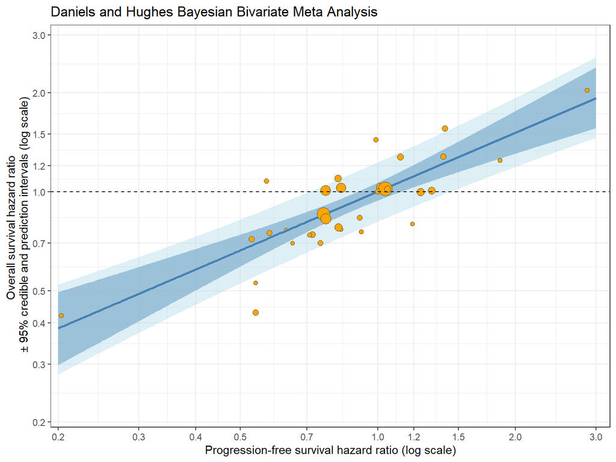

```r
DH.association.plot
```

## Surrogate Threshold Effect

**Show/Hide Code**

```r
candidate.HR.PFS <- DH.pred.df %>%
  filter(upper.pi < 1) %>%
  pull(HR.PFS)

DH.STE <- max(candidate.HR.PFS) |> round(3)
DH.STE
```

```
[1] 0.707
```

## Leave-one-out Cross-validation

Leave-one-out cross-validation (LOOCV) is performed by selecting each trial in a data set in turns and using it as the validation set while using the rest $(n-1)$ of the trials as the training set. This is repeated $n$ times. For each iteration in the LOOCV procedure, models are ﬁtted to the training set, and the dependent variable of interest (target endpoint) is predicted on the basis of the explanatory variable(s) in the models (surrogate endpoint) in the validation set.

Two different criteria were used to assess the performance of each model for each iteration of the LOOCV. For each criterion, the median and range of the output values were used to assess model performance.

### Proportion of actual values from the validation set that lies within the 95% prediction interval from the training set

The steps are as follows:

- Leave out $i-$th study and train the model with remaining $n - 1$ studies.
- Obtain $95\%$ prediction interval for the treatment effect on target endpoint (OS) in the left-out trial, using its surrogate endpoint (PFS) treatment effect.
- Simulate $1000$ OS treatment effects based on normal distribution using the observed OS treatment effect and its standard error from the left-out trial.
- Calculate the proportion of the $1000$ simulated values falling within the prediction interval, $p_i$.
- Repeat these steps for all the studies, leaving out one at a time.
- Calculate $median(p_1, \ldots, p_n)$ and $range(p_1, \ldots, p_n)$.

**Show/Hide Code**

```r
n <- nrow(df1)

prop <- c()

absolute.difference <- c()
```

**Show/Hide Code**

```r
for(i in 1:n){
  df <- df1[-i,]

  DH.data <- list(N = nrow(df),
                  theta_hat = df$OS.ln.HR,
                  gamma_hat = df$PFS.ln.HR,
                  se_theta = df$OS.se,
                  se_gamma = df$PFS.se)

  fit <- DH.model$sample(data = DH.data,
                         chains = 4, parallel_chains = 4,
                         iter_warmup = 500,
                         iter_sampling = 2000,
                         adapt_delta = 0.95,
                         max_treedepth = 25,
                         refresh = 0)

  posterior.draws <- fit$draws(variables = c("alpha", "beta", "tau"),
                                     format = "draws_df")

  new.data <- data.frame(PFS.ln.HR = df1$PFS.ln.HR[i])

  DH.posterior <- posterior.draws$alpha + new.data$PFS.ln.HR * posterior.draws$beta

  u <- rnorm(4 * 2000, 0, sd = posterior.draws$tau)

  DH.predictions <- DH.posterior + u

  # for criterion 1
  DH.pi <- quantile(DH.predictions, probs = c(0.025, 0.975))

  simulated.OS.ln.HR <- rnorm(1000, mean = df1$OS.ln.HR[i], sd = df1$OS.se[i])

  prop[i] <- mean((simulated.OS.ln.HR >= DH.pi["2.5%"]) & (simulated.OS.ln.HR <= DH.pi["97.5%"]))

  # for criterion 2
  DH.fit <- mean(DH.predictions)

  absolute.difference[i] <- abs(df1$OS.ln.HR[i] - DH.fit)
}
```

**Show/Hide Code**

```r
median.prop <- median(prop)
median.prop
```

```
[1] 0.6095
```

**Show/Hide Code**

```r
range.prop <- range(prop)
range.prop
```

```
[1] 0.043 1.000
```

### Absolute difference between mean predicted value and actual value

The absolute difference between the actual log hazard ratio and the predicted log hazard ratio for OS for each trial left out will be recorded.

**Show/Hide Code**

```r
median.absolute.difference <- median(absolute.difference)
median.absolute.difference |> round(3)
```

```
[1] 0.142
```

**Show/Hide Code**

```r
range.absolute.difference <- range(absolute.difference)
range.absolute.difference |> round(3)
```

```
[1] 0.003 0.519
```

## References

Bujkiewicz, Sylwia, Felix Achana, Tasos Papanikos, Richard D. Riley, and Keith R. Abrams. 2026. *TSD 20: Multivariate meta-analysis of summary data for combining treatment effects on correlated outcomes and evaluating surrogate endpoints*. September. https://doi.org/10.15131/shef.data.33848854.v1.

Daniels, Michael J., and Michael D. Hughes. 1997. “Meta-Analysis for the Evaluation of Potential Surrogate Markers.” *Statistics in Medicine* 16 (17): 1965–82. https://doi.org/https://doi.org/10.1002/(SICI)1097-0258(19970915)16:17<1965::AID-SIM630>3.0.CO;2-M.

Vickers, Adrian D. 2025. “A Comparison of the Performance of 6 Surrogacy Models, Including Weighted Linear Regression, Meta-Regression, and Bivariate Meta-Analysis.” *Value in Health* 28 (4): 591–98. https://doi.org/https://doi.org/10.1016/j.jval.2025.01.005.

Vickers, Adrian D., Katherine B. Winfree, Gebra Cuyun Carter, et al. 2019. “Relative Efficacy of Interventions in the Treatment of Second-Line Non-Small Cell Lung Cancer: A Systematic Review and Network Meta-Analysis.” *BMC Cancer* 19. https://api.semanticscholar.org/CorpusID:115155678.